# Regularization

NareshVemula

September 7, 2016

## Regularization and subset selection

```r
library(ISLR)
fix(Hitters)
names(Hitters)
```

```
##  [1] "AtBat"     "Hits"      "HmRun"     "Runs"      "RBI"
##  [6] "Walks"     "Years"     "CAtBat"    "CHits"     "CHmRun"
## [11] "CRuns"     "CRBI"      "CWalks"    "League"    "Division"
## [16] "PutOuts"   "Assists"   "Errors"    "Salary"    "NewLeague"
```

```r
dim(Hitters)
```

```
## [1] 322  20
```

```r
sum(is.na(Hitters$Salary))
```

```
## [1] 59
```

```r
Hitters=na.exclude(Hitters)
```

regsubsets in leaps library helps to choose the subsets

```r
library(leaps)
hitterBestSubset=regsubsets(Salary~.,data = Hitters)
summary(hitterBestSubset)
```

```
## Subset selection object
## Call: regsubsets.formula(Salary ~ ., data = Hitters)
## 19 Variables  (and intercept)
##            Forced in Forced out
## AtBat          FALSE      FALSE
## Hits           FALSE      FALSE
## HmRun          FALSE      FALSE
## Runs           FALSE      FALSE
## RBI            FALSE      FALSE
## Walks          FALSE      FALSE
## Years          FALSE      FALSE
## CAtBat         FALSE      FALSE
## CHits          FALSE      FALSE
## CHmRun         FALSE      FALSE
## CRuns          FALSE      FALSE
## CRBI           FALSE      FALSE
## CWalks         FALSE      FALSE
## LeagueN        FALSE      FALSE
## DivisionW      FALSE      FALSE
## PutOuts        FALSE      FALSE
## Assists        FALSE      FALSE
## Errors         FALSE      FALSE
## NewLeagueN     FALSE      FALSE
## 1 subsets of each size up to 8
## Selection Algorithm: exhaustive
##          AtBat Hits HmRun Runs RBI Walks Years CAtBat CHits CHmRun CRuns
## 1  ( 1 ) " "   " "  " "   " "  " " " "   " "   " "    " "   " "    " "
## 2  ( 1 ) " "   "*"  " "   " "  " " " "   " "   " "    " "   " "    " "
## 3  ( 1 ) " "   "*"  " "   " "  " " " "   " "   " "    " "   " "    " "
## 4  ( 1 ) " "   "*"  " "   " "  " " " "   " "   " "    " "   " "    " "
## 5  ( 1 ) "*"   "*"  " "   " "  " " " "   " "   " "    " "   " "    " "
## 6  ( 1 ) "*"   "*"  " "   " "  " " "*"   " "   " "    " "   " "    " "
## 7  ( 1 ) " "   "*"  " "   " "  " " "*"   " "   "*"    "*"   "*"    " "
## 8  ( 1 ) "*"   "*"  " "   " "  " " "*"   " "   " "    " "   "*"    "*"
##          CRBI CWalks LeagueN DivisionW PutOuts Assists Errors NewLeagueN
## 1  ( 1 ) "*"  " "    " "     " "       " "     " "     " "    " "
## 2  ( 1 ) "*"  " "    " "     " "       " "     " "     " "    " "
## 3  ( 1 ) "*"  " "    " "     " "       "*"     " "     " "    " "
## 4  ( 1 ) "*"  " "    " "     "*"       "*"     " "     " "    " "
## 5  ( 1 ) "*"  " "    " "     "*"       "*"     " "     " "    " "
## 6  ( 1 ) "*"  " "    " "     "*"       "*"     " "     " "    " "
## 7  ( 1 ) " "  " "    " "     "*"       "*"     " "     " "    " "
## 8  ( 1 ) " "  "*"    " "     "*"       "*"     " "     " "    " "
```

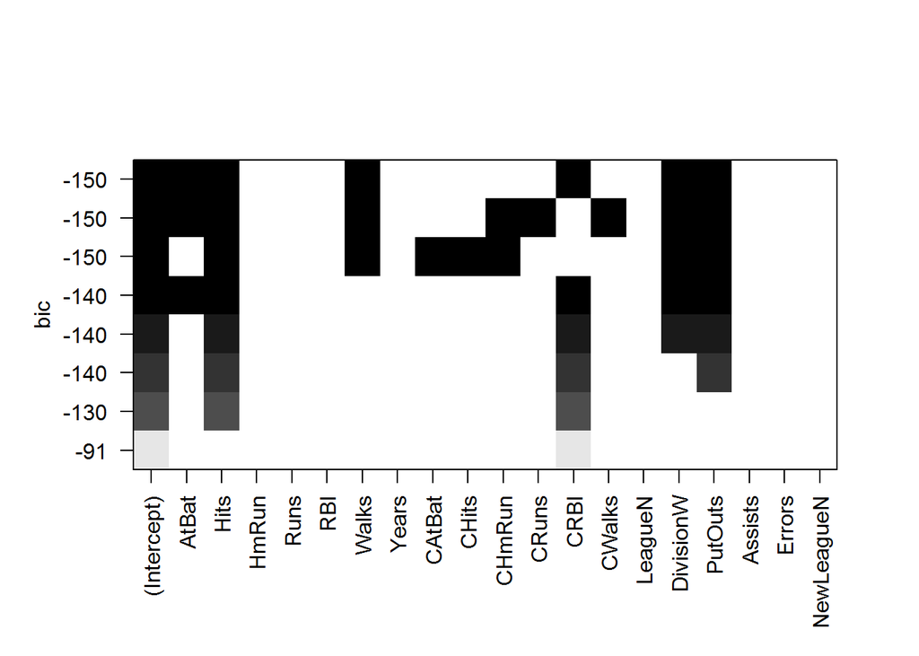

```r
plot(hitterBestSubset)
```

as default regsubsets returns only best 8 subset model, to include all the variables we add a parameter call nvmax

```r
hitterBestSubset19=regsubsets(Salary~.,data = Hitters, nvmax = 19)
BestSummary=summary(hitterBestSubset19)
names(summary(hitterBestSubset19))
```

```
## [1] "which"  "rsq"    "rss"    "adjr2"  "cp"     "bic"    "outmat" "obj"
```

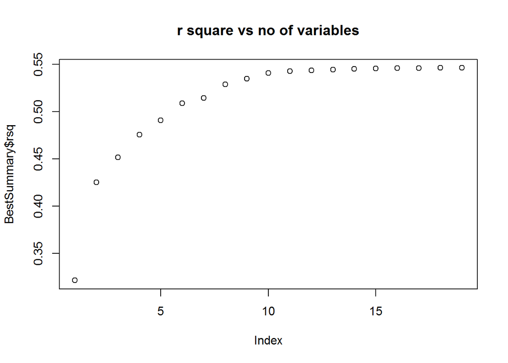

```r
plot(BestSummary$rsq,main = 'r square vs no of variables')
```

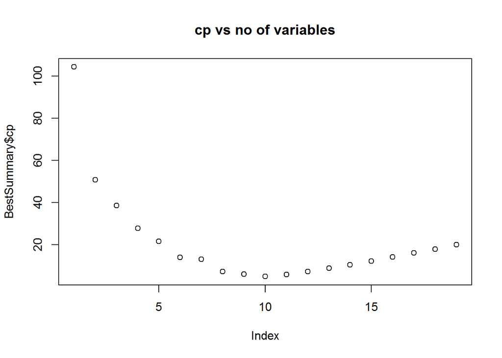

```r
plot(BestSummary$cp,main = 'cp vs no of variables')
```

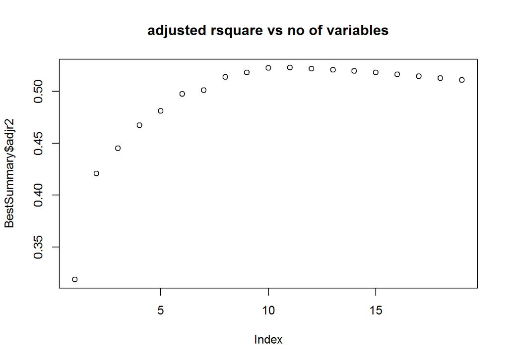

```r
plot(BestSummary$adjr2,main = 'adjusted rsquare vs no of variables')
```

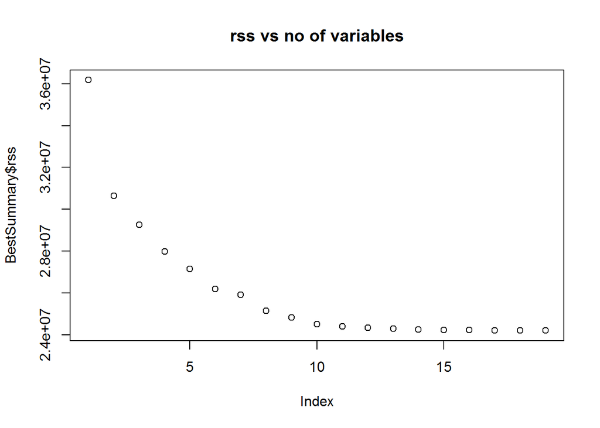

```r
plot(BestSummary$rss,main = 'rss vs no of variables')
```

Best subset selection

```r
which.min(BestSummary$cp)
```

```
## [1] 10
```

```r
which.max(BestSummary$adjr2)
```

```
## [1] 11
```

```r
which.min(BestSummary$bic)
```

```
## [1] 6
```

```r
which.min(BestSummary$rss)
```

```
## [1] 19
```

using the built in plot command of regsubsets

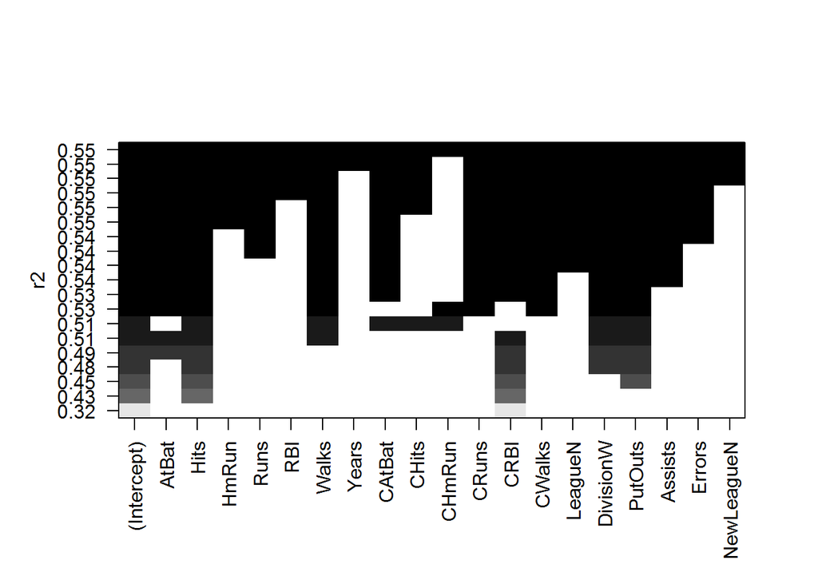

```r
plot(hitterBestSubset19,scale = "r2")
```

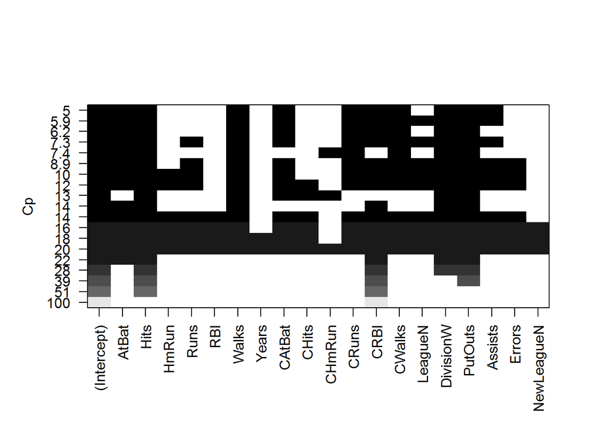

```r
plot(hitterBestSubset19,scale = "Cp")
```

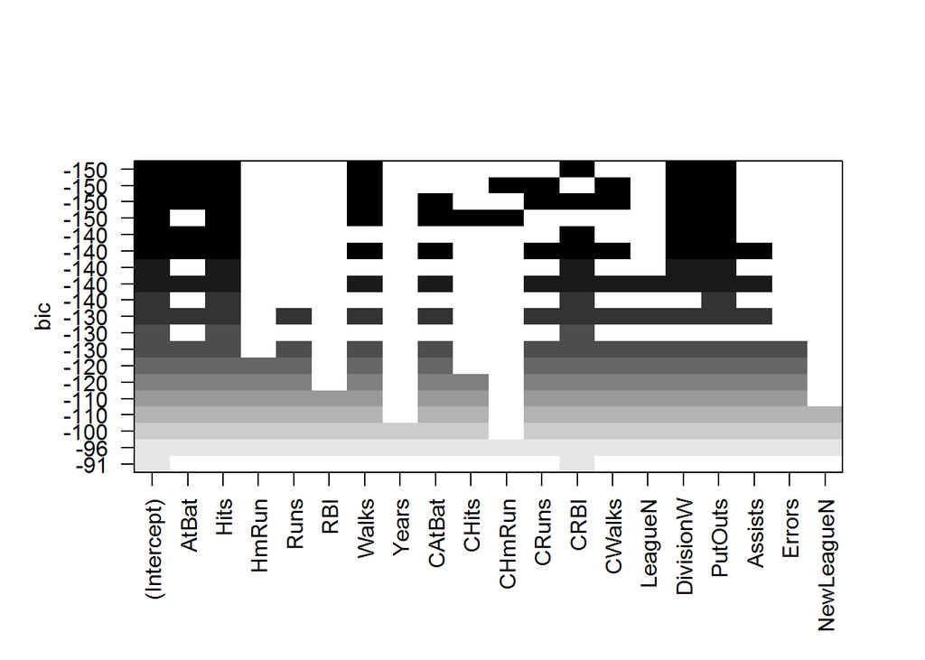

```r
plot(hitterBestSubset19,scale = "bic")
```

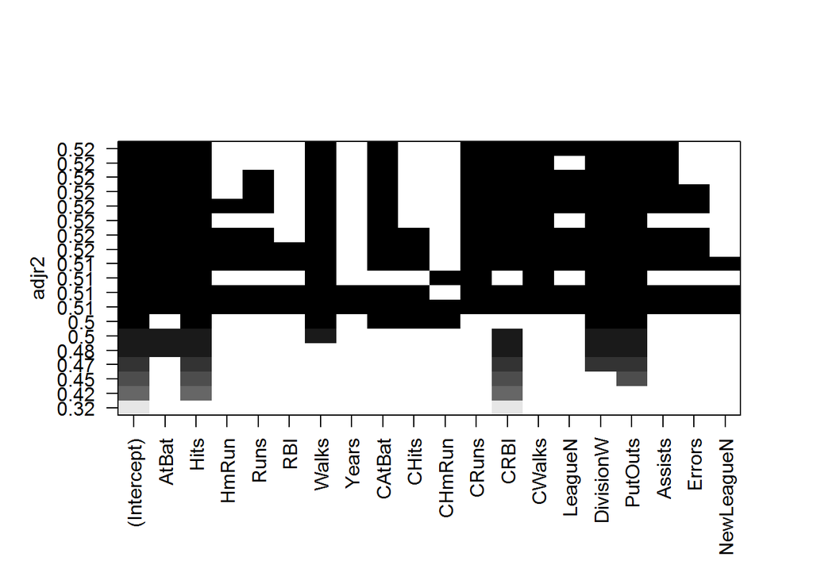

```r
plot(hitterBestSubset19,scale = "adjr2")
```

coefficients of models with optimal values of each statistic

```r
coef(hitterBestSubset19,c(10,11,6,19))
```

```
## [[1]]
##  (Intercept)        AtBat         Hits        Walks       CAtBat
##  162.5354420   -2.1686501    6.9180175    5.7732246   -0.1300798
##        CRuns         CRBI       CWalks    DivisionW      PutOuts
##    1.4082490    0.7743122   -0.8308264 -112.3800575    0.2973726
##      Assists
##    0.2831680
##
## [[2]]
##  (Intercept)        AtBat         Hits        Walks       CAtBat
##  135.7512195   -2.1277482    6.9236994    5.6202755   -0.1389914
##        CRuns         CRBI       CWalks      LeagueN    DivisionW
##    1.4553310    0.7852528   -0.8228559   43.1116152 -111.1460252
##      PutOuts      Assists
##    0.2894087    0.2688277
##
## [[3]]
##  (Intercept)        AtBat         Hits        Walks         CRBI
##   91.5117981   -1.8685892    7.6043976    3.6976468    0.6430169
##    DivisionW      PutOuts
## -122.9515338    0.2643076
##
## [[4]]
##  (Intercept)        AtBat         Hits        HmRun         Runs
##  163.1035878   -1.9798729    7.5007675    4.3308829   -2.3762100
##          RBI        Walks        Years       CAtBat        CHits
##   -1.0449620    6.2312863   -3.4890543   -0.1713405    0.1339910
##       CHmRun        CRuns         CRBI       CWalks      LeagueN
##   -0.1728611    1.4543049    0.8077088   -0.8115709   62.5994230
##    DivisionW      PutOuts      Assists       Errors   NewLeagueN
## -116.8492456    0.2818925    0.3710692   -3.3607605  -24.7623251
```

forward and backward stepwise selection methods

```r
hitterForward=regsubsets(Salary~.,data = Hitters,method = 'forward',nvmax = 19)
summary(hitterForward)
```

```
## Subset selection object
## Call: regsubsets.formula(Salary ~ ., data = Hitters, method = "forward",
##     nvmax = 19)
## 19 Variables  (and intercept)
##            Forced in Forced out
## AtBat          FALSE      FALSE
## Hits           FALSE      FALSE
## HmRun          FALSE      FALSE
## Runs           FALSE      FALSE
## RBI            FALSE      FALSE
## Walks          FALSE      FALSE
## Years          FALSE      FALSE
## CAtBat         FALSE      FALSE
## CHits          FALSE      FALSE
## CHmRun         FALSE      FALSE
## CRuns          FALSE      FALSE
## CRBI           FALSE      FALSE
## CWalks         FALSE      FALSE
## LeagueN        FALSE      FALSE
## DivisionW      FALSE      FALSE
## PutOuts        FALSE      FALSE
## Assists        FALSE      FALSE
## Errors         FALSE      FALSE
## NewLeagueN     FALSE      FALSE
## 1 subsets of each size up to 19
## Selection Algorithm: forward
##           AtBat Hits HmRun Runs RBI Walks Years CAtBat CHits CHmRun CRuns
## 1  ( 1 )  " "   " "  " "   " "  " " " "   " "   " "    " "   " "    " "
## 2  ( 1 )  " "   "*"  " "   " "  " " " "   " "   " "    " "   " "    " "
## 3  ( 1 )  " "   "*"  " "   " "  " " " "   " "   " "    " "   " "    " "
## 4  ( 1 )  " "   "*"  " "   " "  " " " "   " "   " "    " "   " "    " "
## 5  ( 1 )  "*"   "*"  " "   " "  " " " "   " "   " "    " "   " "    " "
## 6  ( 1 )  "*"   "*"  " "   " "  " " "*"   " "   " "    " "   " "    " "
## 7  ( 1 )  "*"   "*"  " "   " "  " " "*"   " "   " "    " "   " "    " "
## 8  ( 1 )  "*"   "*"  " "   " "  " " "*"   " "   " "    " "   " "    "*"
## 9  ( 1 )  "*"   "*"  " "   " "  " " "*"   " "   "*"    " "   " "    "*"
## 10  ( 1 ) "*"   "*"  " "   " "  " " "*"   " "   "*"    " "   " "    "*"
## 11  ( 1 ) "*"   "*"  " "   " "  " " "*"   " "   "*"    " "   " "    "*"
## 12  ( 1 ) "*"   "*"  " "   "*"  " " "*"   " "   "*"    " "   " "    "*"
## 13  ( 1 ) "*"   "*"  " "   "*"  " " "*"   " "   "*"    " "   " "    "*"
```

[output cut: 11 more lines]

```
## 5  ( 1 )  "*"  " "    " "     "*"       "*"     " "     " "    " "
## 6  ( 1 )  "*"  " "    " "     "*"       "*"     " "     " "    " "
## 7  ( 1 )  "*"  "*"    " "     "*"       "*"     " "     " "    " "
## 8  ( 1 )  "*"  "*"    " "     "*"       "*"     " "     " "    " "
## 9  ( 1 )  "*"  "*"    " "     "*"       "*"     " "     " "    " "
## 10  ( 1 ) "*"  "*"    " "     "*"       "*"     "*"     " "    " "
## 11  ( 1 ) "*"  "*"    "*"     "*"       "*"     "*"     " "    " "
## 12  ( 1 ) "*"  "*"    "*"     "*"       "*"     "*"     " "    " "
## 13  ( 1 ) "*"  "*"    "*"     "*"       "*"     "*"     "*"    " "
## 14  ( 1 ) "*"  "*"    "*"     "*"       "*"     "*"     "*"    " "
## 15  ( 1 ) "*"  "*"    "*"     "*"       "*"     "*"     "*"    " "
## 16  ( 1 ) "*"  "*"    "*"     "*"       "*"     "*"     "*"    " "
## 17  ( 1 ) "*"  "*"    "*"     "*"       "*"     "*"     "*"    "*"
## 18  ( 1 ) "*"  "*"    "*"     "*"       "*"     "*"     "*"    "*"
## 19  ( 1 ) "*"  "*"    "*"     "*"       "*"     "*"     "*"    "*"
```

```r
hitterBackward=regsubsets(Salary~.,data = Hitters,method = 'backward',nvmax = 19)
summary(hitterBackward)
```

```
## Subset selection object
## Call: regsubsets.formula(Salary ~ ., data = Hitters, method = "backward",
##     nvmax = 19)
## 19 Variables  (and intercept)
##            Forced in Forced out
## AtBat          FALSE      FALSE
## Hits           FALSE      FALSE
## HmRun          FALSE      FALSE
## Runs           FALSE      FALSE
## RBI            FALSE      FALSE
## Walks          FALSE      FALSE
## Years          FALSE      FALSE
## CAtBat         FALSE      FALSE
## CHits          FALSE      FALSE
## CHmRun         FALSE      FALSE
## CRuns          FALSE      FALSE
## CRBI           FALSE      FALSE
## CWalks         FALSE      FALSE
## LeagueN        FALSE      FALSE
## DivisionW      FALSE      FALSE
## PutOuts        FALSE      FALSE
## Assists        FALSE      FALSE
## Errors         FALSE      FALSE
## NewLeagueN     FALSE      FALSE
## 1 subsets of each size up to 19
## Selection Algorithm: backward
##           AtBat Hits HmRun Runs RBI Walks Years CAtBat CHits CHmRun CRuns
## 1  ( 1 )  " "   " "  " "   " "  " " " "   " "   " "    " "   " "    "*"
## 2  ( 1 )  " "   "*"  " "   " "  " " " "   " "   " "    " "   " "    "*"
## 3  ( 1 )  " "   "*"  " "   " "  " " " "   " "   " "    " "   " "    "*"
## 4  ( 1 )  "*"   "*"  " "   " "  " " " "   " "   " "    " "   " "    "*"
## 5  ( 1 )  "*"   "*"  " "   " "  " " "*"   " "   " "    " "   " "    "*"
## 6  ( 1 )  "*"   "*"  " "   " "  " " "*"   " "   " "    " "   " "    "*"
## 7  ( 1 )  "*"   "*"  " "   " "  " " "*"   " "   " "    " "   " "    "*"
## 8  ( 1 )  "*"   "*"  " "   " "  " " "*"   " "   " "    " "   " "    "*"
## 9  ( 1 )  "*"   "*"  " "   " "  " " "*"   " "   "*"    " "   " "    "*"
## 10  ( 1 ) "*"   "*"  " "   " "  " " "*"   " "   "*"    " "   " "    "*"
## 11  ( 1 ) "*"   "*"  " "   " "  " " "*"   " "   "*"    " "   " "    "*"
## 12  ( 1 ) "*"   "*"  " "   "*"  " " "*"   " "   "*"    " "   " "    "*"
## 13  ( 1 ) "*"   "*"  " "   "*"  " " "*"   " "   "*"    " "   " "    "*"
```

[output cut: 11 more lines]

```
## 5  ( 1 )  " "  " "    " "     " "       "*"     " "     " "    " "
## 6  ( 1 )  " "  " "    " "     "*"       "*"     " "     " "    " "
## 7  ( 1 )  " "  "*"    " "     "*"       "*"     " "     " "    " "
## 8  ( 1 )  "*"  "*"    " "     "*"       "*"     " "     " "    " "
## 9  ( 1 )  "*"  "*"    " "     "*"       "*"     " "     " "    " "
## 10  ( 1 ) "*"  "*"    " "     "*"       "*"     "*"     " "    " "
## 11  ( 1 ) "*"  "*"    "*"     "*"       "*"     "*"     " "    " "
## 12  ( 1 ) "*"  "*"    "*"     "*"       "*"     "*"     " "    " "
## 13  ( 1 ) "*"  "*"    "*"     "*"       "*"     "*"     "*"    " "
## 14  ( 1 ) "*"  "*"    "*"     "*"       "*"     "*"     "*"    " "
## 15  ( 1 ) "*"  "*"    "*"     "*"       "*"     "*"     "*"    " "
## 16  ( 1 ) "*"  "*"    "*"     "*"       "*"     "*"     "*"    " "
## 17  ( 1 ) "*"  "*"    "*"     "*"       "*"     "*"     "*"    "*"
## 18  ( 1 ) "*"  "*"    "*"     "*"       "*"     "*"     "*"    "*"
## 19  ( 1 ) "*"  "*"    "*"     "*"       "*"     "*"     "*"    "*"
```

using cross validation for the model selection splitting the data

```r
set.seed(1)
train=sample(c(T,F),nrow(Hitters),rep=TRUE)
test=!train
```

applying the regsubsets to train the model

```r
HitterValid=regsubsets(Salary~.,data =Hitters[train,],nvmax = 19)
```

building model.matrix to run the validation

```r
HitterTestData=model.matrix(Salary~.,data = Hitters[test,])
str(HitterTestData)
```

```
##  num [1:129, 1:20] 1 1 1 1 1 1 1 1 1 1 ...
##  - attr(*, "dimnames")=List of 2
##   ..$ : chr [1:129] "-Andre Dawson" "-Andres Galarraga" "-Al Newman" "-Argenis Salazar" ...
##   ..$ : chr [1:20] "(Intercept)" "AtBat" "Hits" "HmRun" ...
##  - attr(*, "assign")= int [1:20] 0 1 2 3 4 5 6 7 8 9 ...
##  - attr(*, "contrasts")=List of 3
##   ..$ League   : chr "contr.treatment"
##   ..$ Division : chr "contr.treatment"
##   ..$ NewLeague: chr "contr.treatment"
```

extractig coefficients to perform validation

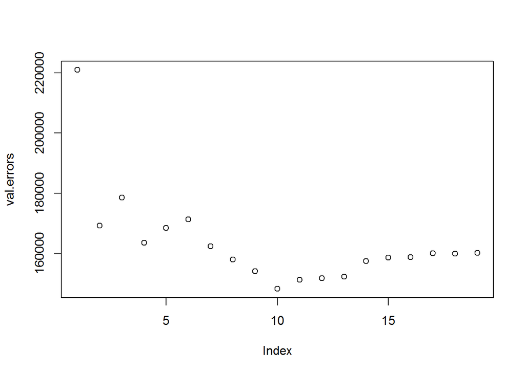

```r
val.errors=rep(NA,19)
for(i in 1:19)
{
  modelCoef=coef(HitterValid,id = i)
  predictTest=HitterTestData[,names(modelCoef)]%*%modelCoef
  val.errors[i]=mean((Hitters$Salary[test]-predictTest)^2)
}
plot(val.errors)
```

```r
val.errors
```

```
##  [1] 220968.0 169157.1 178518.2 163426.1 168418.1 171270.6 162377.1
##  [8] 157909.3 154055.7 148162.1 151156.4 151742.5 152214.5 157358.7
## [15] 158541.4 158743.3 159972.7 159859.8 160105.6
```

```r
which.min(val.errors)
```

```
## [1] 10
```

writing own prediction method using the above code

```r
predictSubsetSelection=function(SubsetModel,testData,modelId,...){
  ModelFormula=as.formula(SubsetModel$call[[2]])
  #converting the data into matix to perform computation
  testMatrix=model.matrix(ModelFormula,testData)
  modelCoef=coef(SubsetModel,id=modelId)
  testMatrix[,names(modelCoef)]%*%modelCoef
}
```

calling this function for all the models

```r
bestModel=regsubsets(Salary~.,data = Hitters,nvmax = 19)
coef(bestModel,10)
```

```
##  (Intercept)        AtBat         Hits        Walks       CAtBat
##  162.5354420   -2.1686501    6.9180175    5.7732246   -0.1300798
##        CRuns         CRBI       CWalks    DivisionW      PutOuts
##    1.4082490    0.7743122   -0.8308264 -112.3800575    0.2973726
##      Assists
##    0.2831680
```

k fold cross validation

```r
k=10
set.seed(1)
folds=sample(1:k,nrow(Hitters),replace = T)
str(folds)
```

```
##  int [1:263] 3 4 6 10 3 9 10 7 7 1 ...
```

```r
#matrix to store the errors in regsubsets cross validation
cvErrors=matrix(nrow = k,ncol = 19)
```

performng CV

```r
for (j in 1:k) {
  bestModel=regsubsets(Salary~.,data = Hitters[folds!=j,],nvmax = 19)
  for(i in 1:19)
  {
    pred=predictSubsetSelection(bestModel,Hitters[folds==j,],i)
    cvErrors[j,i]=mean( (Hitters$Salary[folds==j]-pred)^2)
  }
}
```

mean error computation margin 1 indicates operation on rows margin 2 indicates operation on columns

```r
meanError=apply(cvErrors,MARGIN = 2,mean)
meanError
```

```
##  [1] 160093.5 140196.8 153117.0 151159.3 146841.3 138302.6 144346.2
##  [8] 130207.7 129459.6 125334.7 125153.8 128273.5 133461.0 133974.6
## [15] 131825.7 131882.8 132750.9 133096.2 132804.7
```

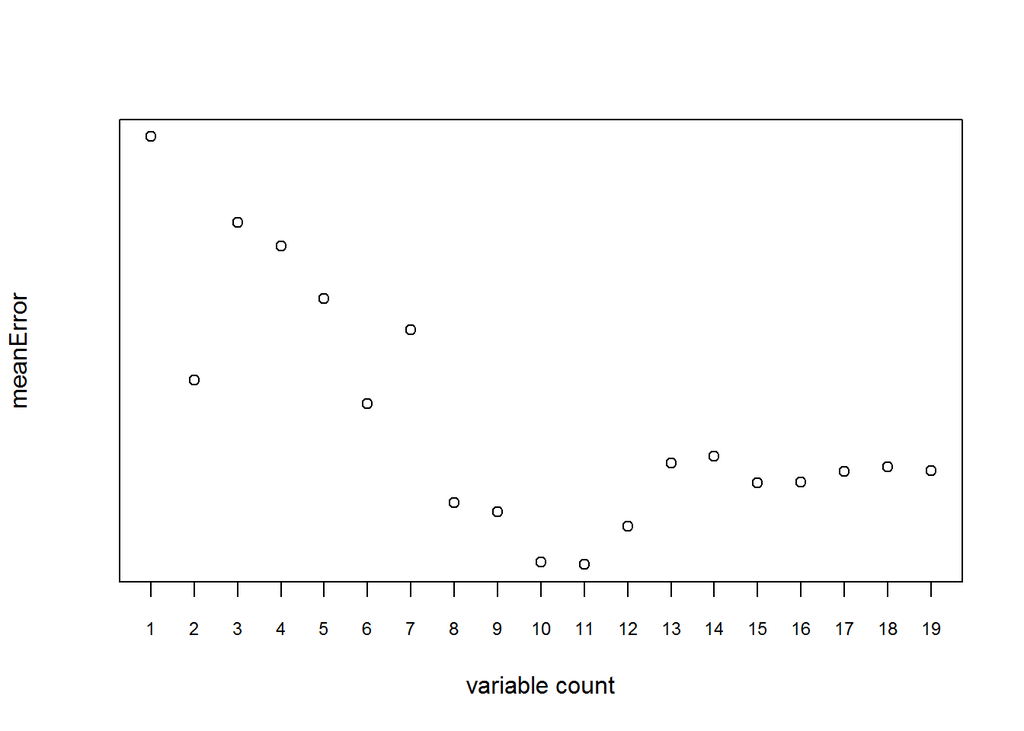

```r
plot(meanError,at=rep(1:19),cex.axis=.75,xlab='variable count')
```

we can use the model with 11 variables

```r
best11model=regsubsets(Salary~.,data = Hitters,nvmax = 19)
coef(best11model,id = 11)
```

```
##  (Intercept)        AtBat         Hits        Walks       CAtBat
##  135.7512195   -2.1277482    6.9236994    5.6202755   -0.1389914
##        CRuns         CRBI       CWalks      LeagueN    DivisionW
##    1.4553310    0.7852528   -0.8228559   43.1116152 -111.1460252
##      PutOuts      Assists
##    0.2894087    0.2688277
```

Lasso and Ridge Regression glmnet package implements lasso and ridge preparing x matrix input data , salary as a y vector - dependent variable

```r
x=model.matrix(Salary~.,data = Hitters)[,-1]
y=Hitters$Salary;
library(glmnet)
```

implementing ridge regression

```r
grid=10^seq(10,-2,length=100)
ridgeModel=glmnet(x,y,alpha = 0,lambda = grid,standardize = T)
coef(ridgeModel)
```

```
## 20 x 100 sparse Matrix of class "dgCMatrix"
```

```
##    [[ suppressing 100 column names 's0', 's1', 's2' ... ]]
```

```
##
## (Intercept)  5.359257e+02  5.359256e+02  5.359256e+02  5.359254e+02
## AtBat        5.443467e-08  7.195940e-08  9.512609e-08  1.257511e-07
## Hits         1.974589e-07  2.610289e-07  3.450649e-07  4.561554e-07
## HmRun        7.956523e-07  1.051805e-06  1.390424e-06  1.838059e-06
## Runs         3.339178e-07  4.414196e-07  5.835307e-07  7.713931e-07
## RBI          3.527222e-07  4.662778e-07  6.163918e-07  8.148335e-07
## Walks        4.151323e-07  5.487803e-07  7.254552e-07  9.590089e-07
## Years        1.697711e-06  2.244274e-06  2.966798e-06  3.921931e-06
## CAtBat       4.673743e-09  6.178412e-09  8.167496e-09  1.079695e-08
## CHits        1.720071e-08  2.273832e-08  3.005872e-08  3.973585e-08
## CHmRun       1.297171e-07  1.714783e-07  2.266842e-07  2.996631e-07
## CRuns        3.450846e-08  4.561814e-08  6.030449e-08  7.971898e-08
## CRBI         3.561348e-08  4.707892e-08  6.223556e-08  8.227173e-08
## CWalks       3.767877e-08  4.980911e-08  6.584471e-08  8.704281e-08
## LeagueN     -5.800263e-07 -7.667601e-07 -1.013611e-06 -1.339933e-06
## DivisionW   -7.807263e-06 -1.032074e-05 -1.364341e-05 -1.803579e-05
## PutOuts      2.180288e-08  2.882212e-08  3.810115e-08  5.036747e-08
## Assists      3.561198e-09  4.707694e-09  6.223294e-09  8.226828e-09
## Errors      -1.660460e-08 -2.195031e-08 -2.901702e-08 -3.835881e-08
## NewLeagueN  -1.152288e-07 -1.523253e-07 -2.013646e-07 -2.661912e-07
##
## (Intercept)  5.359253e+02  5.359251e+02  5.359249e+02  5.359246e+02
## AtBat        1.662355e-07  2.197535e-07  2.905011e-07  3.840251e-07
## Hits         6.030105e-07  7.971441e-07  1.053777e-06  1.393031e-06
## HmRun        2.429805e-06  3.212059e-06  4.246151e-06  5.613159e-06
## Runs         1.019736e-06  1.348031e-06  1.782017e-06  2.355720e-06
## RBI          1.077162e-06  1.423944e-06  1.882370e-06  2.488380e-06
## Walks        1.267753e-06  1.675895e-06  2.215433e-06  2.928671e-06
## Years        5.184561e-06  6.853682e-06  9.060161e-06  1.197699e-05
## CAtBat       1.427293e-08  1.886796e-08  2.494233e-08  3.297227e-08
## CHits        5.252844e-08  6.943949e-08  9.179488e-08  1.213474e-07
## CHmRun       3.961369e-07  5.236695e-07  6.922600e-07  9.151265e-07
## CRuns        1.053838e-07  1.393111e-07  1.841610e-07  2.434499e-07
## CRBI         1.087584e-07  1.437721e-07  1.900582e-07  2.512456e-07
## CWalks       1.150654e-07  1.521097e-07  2.010800e-07  2.658157e-07
## LeagueN     -1.771310e-06 -2.341563e-06 -3.095401e-06 -4.091926e-06
## DivisionW   -2.384225e-05 -3.151805e-05 -4.166500e-05 -5.507866e-05
## PutOuts      6.658282e-08  8.801855e-08  1.163553e-07  1.538148e-07
## Assists      1.087538e-08  1.437661e-08  1.900503e-08  2.512352e-08
```

[output cut: 470 more lines]

```
## RBI           -0.90854849   -0.91183999   -0.91458802   -0.91623008
## Walks          6.19694978    6.19843547    6.19965258    6.20037718
## Years         -3.77022451   -3.74605080   -3.72601133   -3.71403424
## CAtBat        -0.17422443   -0.17460121   -0.17491365   -0.17510063
## CHits          0.21192408    0.21167038    0.21145637    0.21132772
## CHmRun         0.06456861    0.06101687    0.05806358    0.05629004
## CRuns          1.36088218    1.36310421    1.36494921    1.36605490
## CRBI           0.70575245    0.70742622    0.70881996    0.70965516
## CWalks        -0.79492845   -0.79531368   -0.79563082   -0.79582173
## LeagueN       63.39948921   63.40200575   63.40387275   63.40493257
## DivisionW   -117.12031613 -117.10400639 -117.09042529 -117.08243713
## PutOuts        0.28203613    0.28203146    0.28202761    0.28202541
## Assists        0.37276925    0.37294853    0.37309736    0.37318482
## Errors        -3.42611017   -3.42521149   -3.42443980   -3.42400281
## NewLeagueN   -26.02245608  -26.00905121  -25.99761906  -25.99081928
```

```r
dim(coef(ridgeModel))
```

```
## [1]  20 100
```

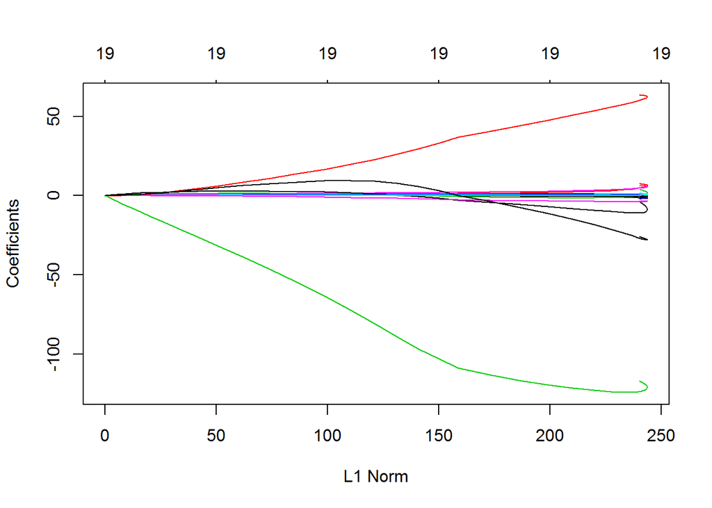

```r
plot(ridgeModel)
```

validating the ridge model

```r
set.seed(1)
train=sample(1:nrow(x),nrow(x)/2)
test=(-train)
table(test)
```

```
## test
## -261 -259 -257 -256 -254 -251 -249 -245 -244 -243 -242 -241 -240 -239 -237
##    1    1    1    1    1    1    1    1    1    1    1    1    1    1    1
## -236 -235 -234 -232 -230 -228 -226 -224 -222 -221 -214 -212 -211 -210 -208
##    1    1    1    1    1    1    1    1    1    1    1    1    1    1    1
## -207 -206 -205 -203 -201 -200 -199 -192 -190 -188 -186 -185 -184 -183 -181
##    1    1    1    1    1    1    1    1    1    1    1    1    1    1    1
## -178 -177 -174 -173 -170 -168 -167 -166 -163 -162 -161 -159 -158 -154 -153
##    1    1    1    1    1    1    1    1    1    1    1    1    1    1    1
## -151 -150 -149 -144 -143 -142 -140 -136 -134 -132 -130 -126 -124 -122 -117
##    1    1    1    1    1    1    1    1    1    1    1    1    1    1    1
## -115 -113 -112 -110 -107 -106 -105 -104 -102 -101 -100  -98  -97  -95  -94
##    1    1    1    1    1    1    1    1    1    1    1    1    1    1    1
##  -93  -92  -91  -83  -80  -77  -75  -73  -71  -70  -69  -67  -66  -65  -64
##    1    1    1    1    1    1    1    1    1    1    1    1    1    1    1
##  -63  -60  -59  -58  -54  -53  -52  -45  -44  -43  -42  -37  -34  -31  -29
##    1    1    1    1    1    1    1    1    1    1    1    1    1    1    1
##  -25  -23  -22  -21  -17  -16  -15  -11   -6   -4   -2
##    1    1    1    1    1    1    1    1    1    1    1
```

```r
y.test=y[test]
```

predicting using lamba 4

```r
ridgeTrain=glmnet(x[train,],y[train],alpha = 0,lambda = grid)
predictTest=predict(ridgeTrain,s = 4,newx = x[test,])
mean((y.test-predictTest)^2)
```

```
## [1] 101186.3
```

using cv’s built in function cv.glmnet

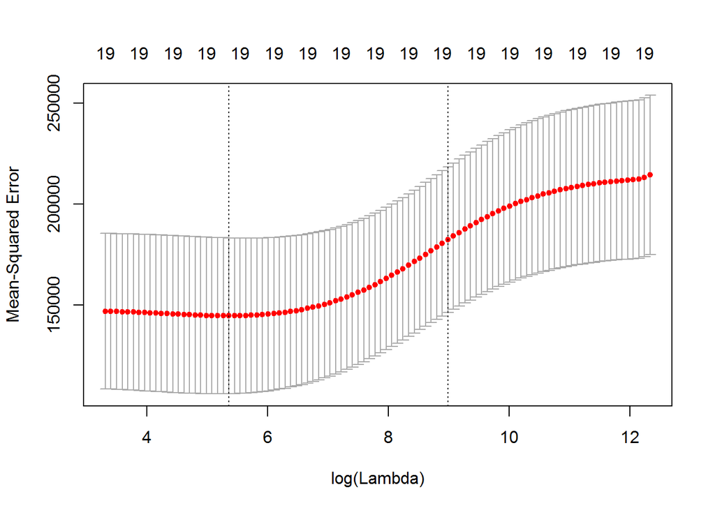

```r
set.seed(1)
CVridge=cv.glmnet(x[train,],y[train],alpha=0)
plot(CVridge)
```

```r
bestLambda=CVridge$lambda.min
predCV=predict(CVridge,s=211.7416,newx=x[test,])
mean((y.test-predCV)^2)
```

```
## [1] 95982.96
```

fitting the new model

```r
finalRidge=glmnet(x,y,alpha = 0,lambda = bestLambda)
coef(finalRidge)
```

```
## 20 x 1 sparse Matrix of class "dgCMatrix"
##                       s0
## (Intercept)   9.81383684
## AtBat         0.03174457
## Hits          1.00837355
## HmRun         0.14062186
## Runs          1.11296019
## RBI           0.87318566
## Walks         1.80365302
## Years         0.13743548
## CAtBat        0.01114900
## CHits         0.06489415
## CHmRun        0.45152976
## CRuns         0.12888607
## CRBI          0.13726927
## CWalks        0.02919186
## LeagueN      27.17300585
## DivisionW   -91.62094993
## PutOuts       0.19145581
## Assists       0.04247849
## Errors       -1.81160164
## NewLeagueN    7.22425927
```

```r
predict(finalRidge,type="coefficients",s=bestLambda)[1:20,]
```

```
##  (Intercept)        AtBat         Hits        HmRun         Runs
##   9.81383684   0.03174457   1.00837355   0.14062186   1.11296019
##          RBI        Walks        Years       CAtBat        CHits
##   0.87318566   1.80365302   0.13743548   0.01114900   0.06489415
##       CHmRun        CRuns         CRBI       CWalks      LeagueN
##   0.45152976   0.12888607   0.13726927   0.02919186  27.17300585
##    DivisionW      PutOuts      Assists       Errors   NewLeagueN
## -91.62094993   0.19145581   0.04247849  -1.81160164   7.22425927
```

working with LASSO let us check whether lasso will beat MSE of 95982.96 CV.

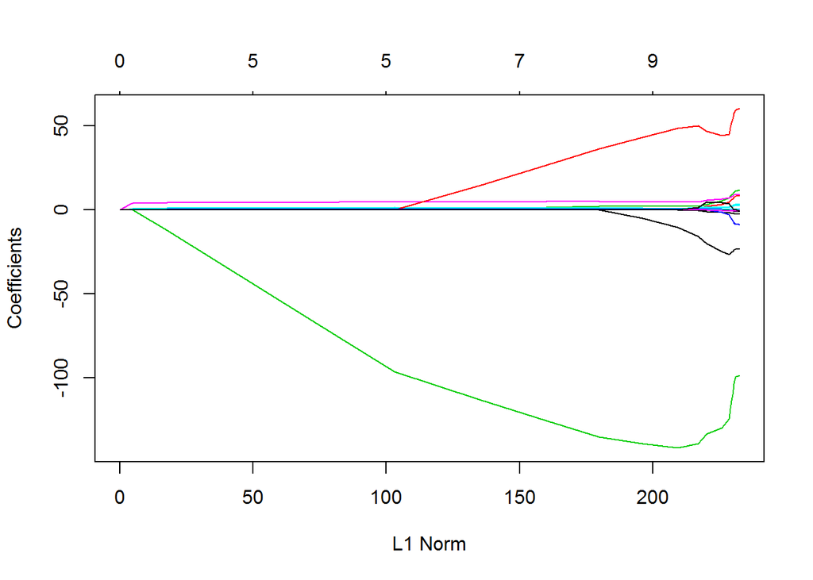

```r
lassoModel=glmnet(x[train,],y[train],alpha = 1,lambda = grid)
plot(lassoModel)
```

we will perform CV

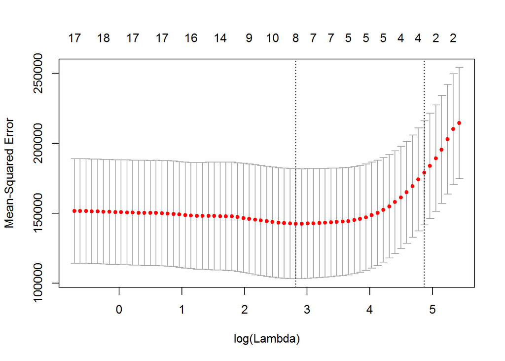

```r
set.seed(1)
lassoCV=cv.glmnet(x[train,],y[train],alpha=1)
plot(lassoCV)
```

```r
bestLassoLambda=lassoCV$lambda.min
lassoPredTest=predict(lassoCV,s=bestLassoLambda,newx = x[test,])
mean((lassoPredTest-y[test])^2)
```

```
## [1] 100838.2
```

building the best lasso with bestlabda

```r
finalLasso=glmnet(x,y,alpha = 1,lambda = bestLassoLambda)
coef(finalLasso)
```

```
## 20 x 1 sparse Matrix of class "dgCMatrix"
##                       s0
## (Intercept)   19.5052237
## AtBat          .
## Hits           1.8702513
## HmRun          .
## Runs           .
## RBI            .
## Walks          2.2185101
## Years          .
## CAtBat         .
## CHits          .
## CHmRun         .
## CRuns          0.2075887
## CRBI           0.4125063
## CWalks         .
## LeagueN        1.7600993
## DivisionW   -103.4996975
## PutOuts        0.2207019
## Assists        .
## Errors         .
## NewLeagueN     .
```

```r
lassoCoef=predict(finalLasso,type='coefficients')[1:20,]
lassoCoef[lassoCoef!=0]
```

```
##  (Intercept)         Hits        Walks        CRuns         CRBI
##   19.5052237    1.8702513    2.2185101    0.2075887    0.4125063
##      LeagueN    DivisionW      PutOuts
##    1.7600993 -103.4996975    0.2207019
```

working with Principal Components regression pls is the necessary package to work on we use CV and scale option to perform cross validation and standardization

```r
library(pls)
PCRModel=pcr(Salary~.,data=Hitters,validation="CV",scale=T)
summary(PCRModel)
```

```
## Data:    X dimension: 263 19
##  Y dimension: 263 1
## Fit method: svdpc
## Number of components considered: 19
##
## VALIDATION: RMSEP
## Cross-validated using 10 random segments.
##        (Intercept)  1 comps  2 comps  3 comps  4 comps  5 comps  6 comps
## CV             452    354.4    351.5    350.9    349.7    344.9    343.6
## adjCV          452    354.0    351.1    350.5    349.2    344.3    342.6
##        7 comps  8 comps  9 comps  10 comps  11 comps  12 comps  13 comps
## CV       346.1    348.5    352.1     351.4     353.3     354.4     354.3
## adjCV    345.2    347.5    350.9     350.0     351.9     352.9     352.9
##        14 comps  15 comps  16 comps  17 comps  18 comps  19 comps
## CV        350.0     349.8     344.4     346.4     345.0     348.5
## adjCV     348.3     348.1     342.6     344.2     342.8     346.0
##
## TRAINING: % variance explained
##         1 comps  2 comps  3 comps  4 comps  5 comps  6 comps  7 comps
## X         38.31    60.16    70.84    79.03    84.29    88.63    92.26
## Salary    40.63    41.58    42.17    43.22    44.90    46.48    46.69
##         8 comps  9 comps  10 comps  11 comps  12 comps  13 comps  14 comps
## X         94.96    96.28     97.26     97.98     98.65     99.15     99.47
## Salary    46.75    46.86     47.76     47.82     47.85     48.10     50.40
##         15 comps  16 comps  17 comps  18 comps  19 comps
## X          99.75     99.89     99.97     99.99    100.00
## Salary     50.55     53.01     53.85     54.61     54.61
```

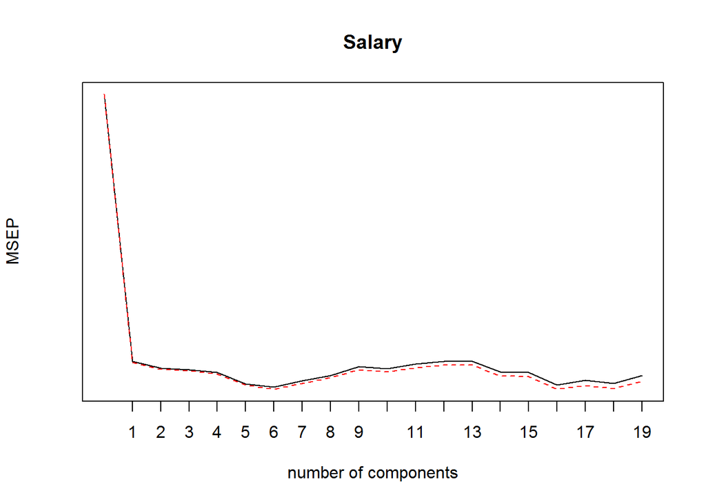

```r
validationplot(PCRModel,val.type = "MSEP",at=1:20)
```

pcr on train and test set

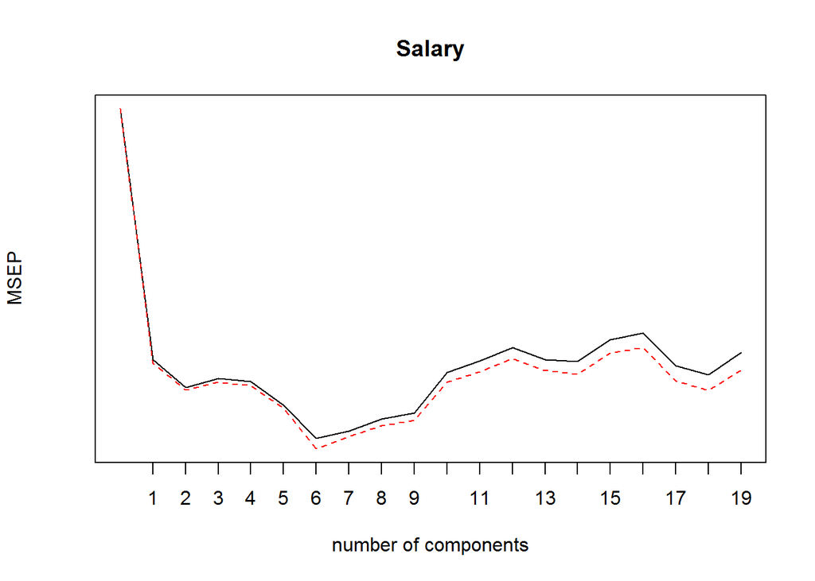

```r
PCRModelTrain=pcr(Salary~.,data=Hitters,subset=train,scale=T,validation='CV')
validationplot(PCRModelTrain,val.type = "MSEP",at=1:20)
```

lowest occuring at 6 PCR

```r
pcrPredict=predict(PCRModelTrain,x[test,],ncomp = 6)
mean((pcrPredict-y[test])^2)
```

```
## [1] 96587.92
```

final fit for pcr

```r
PCRFinal=pcr(y~x,data=Hitters,scale=T,ncomp=6)
summary(PCRFinal)
```

```
## Data:    X dimension: 263 19
##  Y dimension: 263 1
## Fit method: svdpc
## Number of components considered: 6
## TRAINING: % variance explained
##    1 comps  2 comps  3 comps  4 comps  5 comps  6 comps
## X    38.31    60.16    70.84    79.03    84.29    88.63
## y    40.63    41.58    42.17    43.22    44.90    46.48
```

Partial Least Squares regression

```r
set.seed(1)
PartialModel=plsr(Salary~.,data=Hitters,subset=train,scale=T,validation="CV")
summary(PartialModel)
```

```
## Data:    X dimension: 131 19
##  Y dimension: 131 1
## Fit method: kernelpls
## Number of components considered: 19
##
## VALIDATION: RMSEP
## Cross-validated using 10 random segments.
##        (Intercept)  1 comps  2 comps  3 comps  4 comps  5 comps  6 comps
## CV           464.6    394.2    391.5    393.1    395.0    415.0    424.0
## adjCV        464.6    393.4    390.2    391.1    392.9    411.5    418.8
##        7 comps  8 comps  9 comps  10 comps  11 comps  12 comps  13 comps
## CV       424.5    415.8    404.6     407.1     412.0     414.4     410.3
## adjCV    418.9    411.4    400.7     402.2     407.2     409.3     405.6
##        14 comps  15 comps  16 comps  17 comps  18 comps  19 comps
## CV        406.2     408.6     410.5     408.8     407.8     410.2
## adjCV     401.8     403.9     405.6     404.1     403.2     405.5
##
## TRAINING: % variance explained
##         1 comps  2 comps  3 comps  4 comps  5 comps  6 comps  7 comps
## X         38.12    53.46    66.05    74.49    79.33    84.56    87.09
## Salary    33.58    38.96    41.57    42.43    44.04    45.59    47.05
##         8 comps  9 comps  10 comps  11 comps  12 comps  13 comps  14 comps
## X         90.74    92.55     93.94     97.23     97.88     98.35     98.85
## Salary    47.53    48.42     49.68     50.04     50.54     50.78     50.92
##         15 comps  16 comps  17 comps  18 comps  19 comps
## X          99.11     99.43     99.78     99.99    100.00
## Salary     51.04     51.11     51.15     51.16     51.18
```

Applied Exercises

```r
x=rnorm(100)
e=rnorm(100)
a=4;b=3;c=2;d=1
y=a+b*x+c*x^2+d*x^3+e
```